# **The Top Twitch Streamers Analysis Tutorial**

by Aaron Oh, Kevin Chong, Haider Sajid, Rohith Chandu

[figure not shown]

# **Introduction**

This Data Science Tutorial is brought to you by the 4 man team from the University of Maryland. We will be doing an analysis on a data set from the top 1000 Twitch streamers from around the world. The Twitch data set includes different types of data on streamers such as the number of followers, number of average viewers, watch time, and other relevant types of data about a Twitch streamer which we will be analyzing to determine how and what makes a Twitch streamer successful.

# **Motivation**

So why is this important in Data Science? Not only will it be beneficial for Twitch streamers, but it will also benefit others who are interested on how and why streaming on Twitch is so popular. By data scraping, we can figure out numerous things such as whether or not mature rated content is more advantageous when trying to gain followers. We can also dissect whether followers gained affects stream time or vice versa. All these things can contribute to learning more about the Twitch streaming community. It can help new creators discover the best/and fastest way to become popular on this streaming platform as well as give insight on why Twitch streaming is such a popular platform among this generation.

# **Background Information**

Twitch is an American video live streaming service that officially launched in 2011. The streaming service focuses on video game live streaming. Not only do they broadcast epsorts competions, but they also offer creative content and music broadcasts as well as "in real life" streams. The platform also creates a learning environment and is often used for video game tutorials. The streaming service is not only limited to learning about video games, but can also be used for learning software development, with streamers broadcasting progamming projects and discussing their work with the community. Twitch had more than 100 million viewers per month by 2015. In 2017, Twitch also remained the leader of live streaming video services for video games in the USA as well as having an advantage over the popular YouTube gaming. As of February 2020, the streaming service had 3 million broadcasters monthly, but also 15 million daily active users, with on average 1.4 million concurrent users. Twitch had over 27,000 partner channels as of May 2018.

# **Data Scraping**

Before we begin we will be sourcing our data from [this website](https://www.kaggle.com/aayushmishra1512/twitchdata). This website contains the CSV (comma-separated values) file on the top 1000 Twitch streamers. The dataset also includes 11 columns of different types of data on Twitch streamers.

**Set Up**

First we will import the necessary packages being used in our tutorial. These packages will essentially allow us to utilize different types of functions in order to represent our data visually using different kinds of graphs. Also, we are able to upload our downloaded csv file through here.

```python
import pandas as pd
from google.colab import files
import numpy as np
import matplotlib.pyplot as plt
from sklearn import linear_model
import io
import seaborn as sns
uploaded = files.upload()
```

Upload widget is only available when the cell has been executed in the current browser session. Please rerun this cell to enable.

```
Saving twitchdata-update.csv to twitchdata-update (4).csv
```

# **Reading The Data**

Now we will begin reading the uploaded csv file using pandas and viewing the dataset on the top 1000 twitch streamers.

```python
df = pd.read_csv(io.BytesIO(uploaded['twitchdata-update.csv']))
df
```

|  | Channel | Watch time(Minutes) | Stream time(minutes) | Peak viewers | Average viewers | Followers | Followers gained | Views gained | Partnered | Mature | Language |
| --- | --- | --- | --- | --- | --- | --- | --- | --- | --- | --- | --- |
| 0 | xQcOW | 6196161750 | 215250 | 222720 | 27716 | 3246298 | 1734810 | 93036735 | True | False | English |
| 1 | summit1g | 6091677300 | 211845 | 310998 | 25610 | 5310163 | 1370184 | 89705964 | True | False | English |
| 2 | Gaules | 5644590915 | 515280 | 387315 | 10976 | 1767635 | 1023779 | 102611607 | True | True | Portuguese |
| 3 | ESL_CSGO | 3970318140 | 517740 | 300575 | 7714 | 3944850 | 703986 | 106546942 | True | False | English |
| 4 | Tfue | 3671000070 | 123660 | 285644 | 29602 | 8938903 | 2068424 | 78998587 | True | False | English |
| ... | ... | ... | ... | ... | ... | ... | ... | ... | ... | ... | ... |
| 995 | LITkillah | 122524635 | 13560 | 21359 | 9104 | 601927 | 562691 | 2162107 | True | False | Spanish |
| 996 | 빅헤드 (bighead033) | 122523705 | 153000 | 3940 | 793 | 213212 | 52289 | 4399897 | True | False | Korean |
| 997 | 마스카 (newmasca) | 122452320 | 217410 | 6431 | 567 | 109068 | -4942 | 3417970 | True | False | Korean |
| 998 | AndyMilonakis | 122311065 | 104745 | 10543 | 1153 | 547446 | 109111 | 3926918 | True | False | English |
| 999 | Remx | 122192850 | 99180 | 13788 | 1205 | 178553 | 59432 | 2049420 | True | False | French |

1000 rows × 11 columns

This command will give us the top 5 Twitch channels from the dataset. We will also tidy up our data by removing any data that may have no use towards our analysis.

```python
df.pop('Language')
df.head()
```

|  | Channel | Watch time(Minutes) | Stream time(minutes) | Peak viewers | Average viewers | Followers | Followers gained | Views gained | Partnered | Mature |
| --- | --- | --- | --- | --- | --- | --- | --- | --- | --- | --- |
| 0 | xQcOW | 6196161750 | 215250 | 222720 | 27716 | 3246298 | 1734810 | 93036735 | True | False |
| 1 | summit1g | 6091677300 | 211845 | 310998 | 25610 | 5310163 | 1370184 | 89705964 | True | False |
| 2 | Gaules | 5644590915 | 515280 | 387315 | 10976 | 1767635 | 1023779 | 102611607 | True | True |
| 3 | ESL_CSGO | 3970318140 | 517740 | 300575 | 7714 | 3944850 | 703986 | 106546942 | True | False |
| 4 | Tfue | 3671000070 | 123660 | 285644 | 29602 | 8938903 | 2068424 | 78998587 | True | False |

# **Data Vizualization and Analysis**

By creating a line plot of the top 20 streamers and their respective stream times, we can determine whether or not streaming time contributes to popularity of a streamer. We see here that we also used a seaborn plot in order to create a line graph to view the correlation between stream time and watch time. If you would like to learn more about seaborn and its plotting function visit the link [here](https://seaborn.pydata.org/introduction.html).

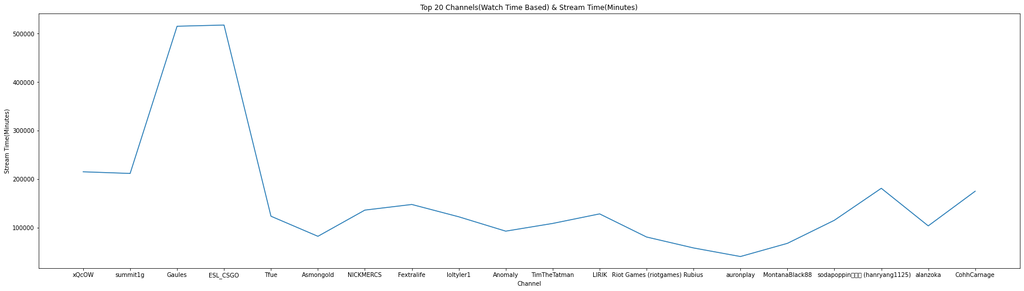

```python
topfive = df.head(20)
channels = topfive['Channel']
stream = topfive['Stream time(minutes)']
plt.subplots(figsize = (30,8))
sns.lineplot(x=channels, y=stream, data=topfive)
plt.title("Top 20 Channels(Watch Time Based) & Stream Time(Minutes)")
plt.xlabel("Channel")
plt.ylabel("Stream Time(Minutes)")
```

# **Approach**

After a closer look at our data set, we observed that the top 5 streamers in general stream for longer periods of time. This brought up the question of whether or not the top streamers get their views and followers during the stream or after the stream (Twitch Recaps). We wanted to determine if there was a relationship between watch/stream time, viewers, and followers. We also wanted to see if mature content was more advantageous when it comes to watch time/popularity in comparison to the opposite. Since each streamer had their unique data set, graphs such as violin plots would not be helpful. However, bar graphs, line graphs, pie charts, and other plots that showed differences in our data (specifically the trend of different streamers) were paramount. We first wanted to see the correlation between the twitch categories in the data set.

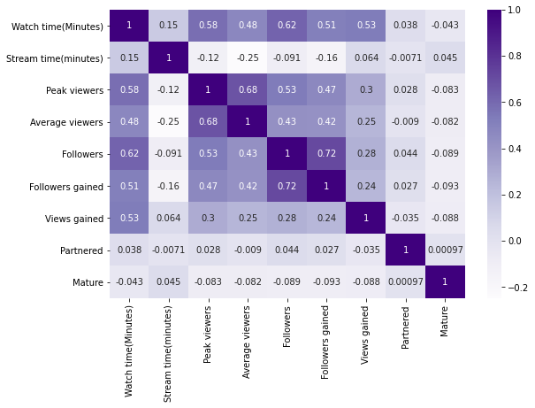

```python
plt.figure(figsize=(9,6))
sns.heatmap(df.corr(), annot=True, cmap='Purples')
plt.show()
```

Here we have a heat map. This is another great visiual data representation given to us by the seaborn package. The heat map is able to tell us how strong the correlation between two data categories are using color shade. The darker the shade of purple means that they will have a stronger correlation while lighter shades have a weaker correlation. In this heat map we can see that other than the fully purple blocks along the diagonal, the second highest value is 0.72 between followers and followers gained. From this map, we can also observe that there are rather high correlations between followers and watch time, peak viewers and average viewers, and followers and followers gained.

By creating a bar plot with the top 20 twitch streamers and their average viewers per stream, we can determine if the best streamers get their views/popularity after or during a stream.

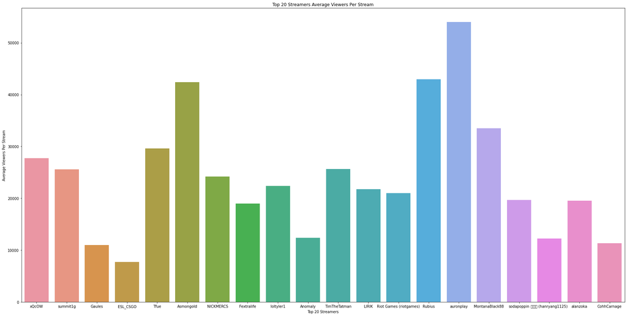

```python
topfive = df.head(20)
plt.figure(figsize=(30,15))
channels = topfive['Channel']
peak = topfive['Average viewers']
sns.barplot(x=channels[:],y=peak[:])
plt.xlabel("Top 20 Streamers")
plt.ylabel("Average Viewers Per Stream")
plt.title("Top 20 Streamers Average Viewers Per Stream")
plt.show()
```

Based on the barplot, it can be observed that the top 5 streamers have rather less average viewers per stream compared to the right side of the bar plot. This can insinuate that the top 5 streamers get their views and popularity after a stream has ended on other platforms other than Twitch such as YouTube or TikTok. While the other streamers are getting their popularity and viewers during their streams.

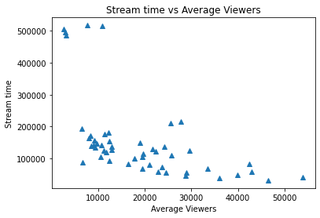

```python
%matplotlib inline
top = df.head(50)
avgv = top["Average viewers"]
stream = top["Stream time(minutes)"]
plt.title("Stream time vs Average Viewers")
plt.xlabel("Average Viewers")
plt.ylabel("Stream time")
plt.plot(avgv, stream, "^")
```

By creating a pie chart we will be able to visualize which channels are the top 10 and consist of the majority of average viewers on the platform.

```python
data_generation =  df.groupby('Channel', as_index=False)['Average viewers'].sum().sort_values(by='Average viewers', ascending=False)
data_generation = data_generation.head(10)
data_generation
```

|  | Channel | Average viewers |
| --- | --- | --- |
| 741 | dota2ti | 147643 |
| 742 | dota2ti_ru | 126232 |
| 700 | auronplay | 53986 |
| 323 | LCS | 46459 |
| 506 | Rubius | 42948 |
| 45 | Asmongold | 42414 |
| 322 | LCK_Korea | 39848 |
| 502 | RocketLeague | 36086 |
| 321 | LCK | 36030 |
| 292 | KEEMSTAR | 35333 |

```
 [Text(0.7941538315885686, 0.7611305353046846, 'dota2ti'),
 [Text(0.43317481723012824, 0.41516211016619153, '24.3%'),
```

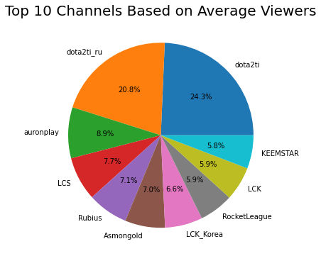

```python
plt.figure(figsize=(6,6))
plt.title('Top 10 Channels Based on Average Viewers', fontsize=20)
avg = data_generation["Average viewers"].head(10)
channels = data_generation["Channel"].head(10)
plt.pie(avg, explode=None, labels=channels, autopct='%1.1f%%')
```

```python
data_generation =  df.groupby('Channel', as_index=False)['Followers'].sum().sort_values(by='Followers', ascending=False)
data_generation = data_generation.head(10)
data_generation
```

|  | Channel | Followers |
| --- | --- | --- |
| 600 | Tfue | 8938903 |
| 863 | shroud | 7744066 |
| 395 | Myth | 6726893 |
| 506 | Rubius | 5751354 |
| 841 | pokimane | 5367605 |
| 872 | summit1g | 5310163 |
| 612 | TimTheTatman | 5265659 |
| 734 | dakotaz | 4520305 |
| 493 | Riot Games (riotgames) | 4487489 |
| 156 | DrDisrespect | 4450718 |

In order to determine if there is a direct correlation between average viewers and follower count, we would need to create another pie chart which displays the top channels based on total followers.

```
 [Text(0.9759364745885837, 0.5074918694596073, 'Tfue'),
 [Text(0.5323289861392274, 0.2768137469779676, '15.3%'),
```

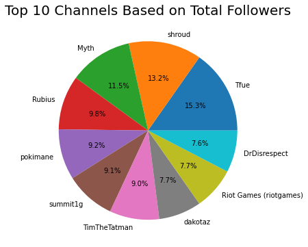

```python
plt.figure(figsize=(6,6))
plt.title('Top 10 Channels Based on Total Followers', fontsize=20)
fol = data_generation["Followers"].head(10)
channels = data_generation["Channel"].head(10)
plt.pie(fol, explode=None, labels=channels, autopct='%1.1f%%')
```

Based on the above pie chart which displays the top 10 channels based on total followers, we are able to see that the top 5 channels in terms of followers are Tfue, shroud, Myth, Rubius, and Pokimane. When looking for any correlation between the top channels in terms of average viewers in comparison to the top channels in terms of total followers, based on comparing the two pie charts we can see that there is no direct correlation. Out of these 10 channels in each top 10 pie chart, only the channel “rubius” appears in both of the charts. This indicates that the total amount of followers a channel has does not have a direct impact on thee amount of average viewers that channel received.

By creating a bar graph with mature content total followers versus non-mature content total followers, we can see whether there are more followers that enjoy mature versus the latter.

```
<BarContainer object of 1000 artists>
```

[figure not shown]

```python
plt.title("Total Followers based on Mature Content (Billions)")
plt.xlabel("Mature")
plt.xticks(np.arange(2), ['True', 'False'])
plt.ylim(3660,9000000)
plt.ylabel("Followers")
plt.bar(df['Mature'], df['Followers'])
```

```python
data_generation =  df.groupby('Channel', as_index=False)['Peak viewers'].sum().sort_values(by='Peak viewers', ascending=False)
data_generation = data_generation.head(10)
data_generation
```

|  | Channel | Peak viewers |
| --- | --- | --- |
| 493 | Riot Games (riotgames) | 639375 |
| 603 | TheGrefg | 538444 |
| 741 | dota2ti | 483530 |
| 863 | shroud | 471281 |
| 742 | dota2ti_ru | 457060 |
| 226 | Gaules | 387315 |
| 731 | csgomc_ru | 364816 |
| 656 | Warframe | 346131 |
| 569 | StarLadder_cs_en | 329195 |
| 287 | JokerdTV | 319862 |

```
 [Text(0.9841179681772011, 0.49143852587152487, 'Riot Games (riotgames)'),
 [Text(0.536791619005746, 0.26805737774810445, '14.7%'),
```

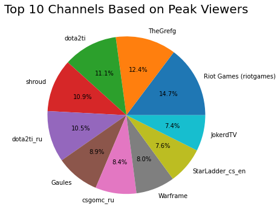

```python
plt.figure(figsize=(6,6))
plt.title('Top 10 Channels Based on Peak Viewers', fontsize=20)
avg = data_generation["Peak viewers"].head(10)
channels = data_generation["Channel"].head(10)
plt.pie(avg, explode=None, labels=channels, autopct='%1.1f%%')
```

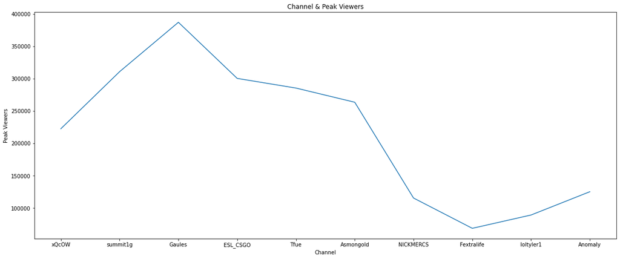

```python
topfive = df.head(10)
channels = topfive['Channel']
peak = topfive['Peak viewers']
plt.subplots(figsize = (20,8))
sns.lineplot(x=channels, y=peak, data=topfive)
plt.title("Channel & Peak Viewers")
plt.xlabel("Channel")
plt.ylabel("Peak Viewers")
```

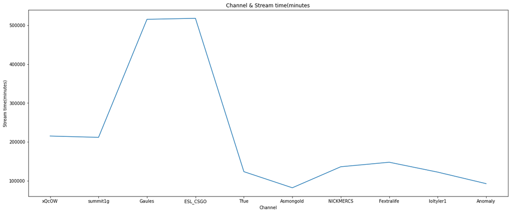

```python
topfive = df.head(10)
channels = topfive['Channel']
peak = topfive['Stream time(minutes)']
plt.subplots(figsize = (20,8))
sns.lineplot(x=channels, y=peak, data=topfive)
plt.title("Channel & Stream time(minutes")
plt.xlabel("Channel")
plt.ylabel("Stream time(minutes)")
```

```python
data_check =  df.groupby('Channel', as_index=False)['Views gained'].sum().sort_values(by='Views gained', ascending=False)
data_check = data_check.head(10)
data_check
```

|  | Channel | Views gained |
| --- | --- | --- |
| 206 | Fextralife | 670137548 |
| 265 | Igromania | 115312954 |
| 172 | ESL_CSGO | 106546942 |
| 226 | Gaules | 102611607 |
| 893 | xQcOW | 93036735 |
| 245 | HGmony | 90310969 |
| 872 | summit1g | 89705964 |
| 141 | Destructoid | 87603521 |
| 105 | Chess | 84500786 |
| 600 | Tfue | 78998587 |

```python
data_check1 =  df.groupby('Channel', as_index=False)['Followers gained'].sum().sort_values(by='Followers gained', ascending=False)
data_check1 = data_check1.head(10)
data_check1
```

|  | Channel | Followers gained |
| --- | --- | --- |
| 700 | auronplay | 3966525 |
| 506 | Rubius | 3820532 |
| 603 | TheGrefg | 3593081 |
| 85 | Bugha | 2220765 |
| 841 | pokimane | 2085831 |
| 600 | Tfue | 2068424 |
| 216 | Fresh | 1875187 |
| 509 | SLAKUN10 | 1874846 |
| 893 | xQcOW | 1734810 |
| 110 | Clix | 1687923 |

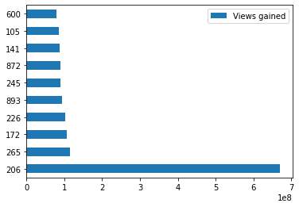

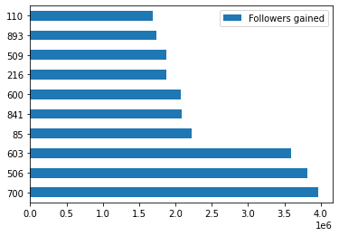

```python
data_check.plot(kind="barh", fontsize=10)
data_check1.plot(kind="barh", fontsize=10)
```

# **Conclusion**

The data that we analyzed helped us have a better understanding about what really makes a twitch streamer be in the top percentile. Based on the analysis of each subcategory, some streamers had a lot more peak viewers than they did average viewers, some streamers had a lot more average view time than they did averager viewers, and some had a lot more followers than other. All of this information helped us determine that to be a top streamer, there are a variety of different factors that come into play.